Machine Learning I

# Analysis of customer churn

Jupyter Notebook Documentation

**Supervised Learning**

Author Anna Kopecny

Author Adil Zhumagaliyev

Author Alisha Utegenova

Author Assylbek Omarov

**Professor:** prof. Ing. Tomáś Kliegr, Ph.D.

**Seminar:** Monday 18:00 - 19:30

Summer Semester 2026

# Business Understanding

Customer churn — the decision of a customer to discontinue their subscription — is one of the most costly problems in the telecommunications industry. Acquiring a new customer is estimated to cost five to seven times more than retaining an existing one, making early identification of at-risk customers a high-value business objective.

This project analyses a dataset from a fictional telecommunications company (IBM Telco Customer Churn dataset) containing information on 7,043 customers, including their demographics, subscribed services, contract type, billing information, and whether they churned within the last month.

**Business objective:** Build a binary classification model that identifies customers likely to churn. This will enable other departments such as for instance the CRM department to take proactive retention actions accordingly.

**Success criteria:** We optimise for ROC-AUC as the primary metric, as the business deployment scenario is a ranked customer list. The retention team can later directly adress the top-k highest-risk customers subject to budget constraints. A secondary threshold-tuned F1-score is reported to assess classification performance at a fixed operating point.

**Target variable:** `Churn` — binary, where `1` = customer churned, `0` = retained (not churned).

The dataset was sourced from the publicly available [IBM Telco Customer Churn dataset](https://www.kaggle.com/datasets/blastchar/telco-customer-churn).

### Customizations

**Instance of interest:** The instance selected for local explanation is the customer in the test set for whom the best Random Forest model predicts the highest churn probability. This choice ensures the explanations (SHAP, LIME, Anchors) are applied to a clear, unambiguous case where the model is most confident, making the resulting rules easier to interpret and validate.

**Attribute of interest:** The attribute selected for counterfactual analysis is `Contract` — the type of subscription agreement (Month-to-month, One year, Two year). This feature is chosen because it is both the strongest predictor of churn identified in EDA and, crucially, one that a retention team can realistically influence by offering a customer an incentive to commit to a longer-term contract.

**Cost matrix:** Our cost matrix reflects an asymmetric business consequences of misclassification. Since acquiring a new customer costs (depending on study and industry) five to 25 times more than retaining an existing one (Harvard Business Review, 2014), a missed churner (false negative) is substantially more damaging than a wasted retention offer (false positive). The following costs are therefore assigned:

|  | Predicted Retained (0) | Predicted Churned (1) |
| --- | --- | --- |
| **Actually Retained (0)** | TN = 0 | FP = 1 |
| **Actually Churned (1)** | FN = 5 | TP = 0 |

A false negative carries a cost of 5, reflecting the estimated relative cost of customer acquisition over retention. A false positive carries a cost of 1, representing the marginal cost of an unnecessary retention offer. True positives and true negatives incur no cost.

Source to the Harvard Article: [Harvard Business Review, 2014](https://hbr.org/2014/10/the-value-of-keeping-the-right-customers).

```python
#%pip install -r ../requirements.txt

# Data Manipulation
import pandas as pd
import numpy as np

# Visualizations
import matplotlib as mpl
import matplotlib.pyplot as plt
import seaborn as sns
from sklearn.tree import export_graphviz
import graphviz
from IPython.display import display, HTML

# Preprocessing
import sklearn
from sklearn.base import BaseEstimator, TransformerMixin
from sklearn.preprocessing import OneHotEncoder
from sklearn.preprocessing import OrdinalEncoder
from sklearn.compose import ColumnTransformer
from sklearn.preprocessing import StandardScaler
from imblearn.over_sampling import RandomOverSampler, SMOTENC
from imblearn.under_sampling import RandomUnderSampler
from imblearn.pipeline import Pipeline as ImbPipeline
from sklearn.preprocessing import LabelEncoder

# Model
from sklearn.dummy import DummyClassifier
from sklearn.ensemble import IsolationForest, RandomForestClassifier
from sklearn.model_selection import train_test_split, StratifiedKFold, GridSearchCV
from sklearn.tree import DecisionTreeClassifier
from sklearn.neural_network import MLPClassifier

# Evaluation
from sklearn.metrics import accuracy_score, precision_score, recall_score, f1_score, roc_auc_score, classification_report, confusion_matrix, ConfusionMatrixDisplay, RocCurveDisplay
from sklearn.model_selection import cross_val_predict

# Interpretation
from sklearn.tree import plot_tree
import shap
from lime.lime_tabular import LimeTabularExplainer
from anchor import anchor_tabular

# Others
import warnings
from sklearn.exceptions import NotFittedError
```

```python
# Settings
SEED = 42
np.random.seed(SEED)
#tf.random.set_seed(SEED)
#random.seed(SEED)
#torch.manual_seed(SEED)
#torch.use_deterministic_algorithms(True)

warnings.filterwarnings("ignore")

my_palette = ["#718096", "#469CDA"]
my_color1 = my_palette[0]
my_color2 = my_palette[1]

mpl.rcParams.update({
    # Figure
    "figure.figsize": (10, 6),
    "figure.dpi": 100,
    "savefig.dpi": 300,
    "figure.facecolor": "white",
    "figure.titlesize": 20,
    "figure.titleweight": "bold",

    # Fonts
    "font.size": 13,
    "axes.titlesize": 15,
    "axes.titleweight": "bold",
    "axes.labelsize": 13,
    "legend.fontsize": 11,

    # Grid
    "axes.grid": True,
    "grid.alpha": 0.3,
    "grid.linestyle": "--",

    # Lines
    "lines.linewidth": 2,

    # Cleaner look
    "axes.spines.top": False,
    "axes.spines.right": False
})
```

# 1 Basic Data Operations

```python
df = pd.read_csv("../data/churn.csv")
```

```python
df.head()
```

|  | customerID | gender | SeniorCitizen | Partner | Dependents | tenure | PhoneService | MultipleLines | InternetService | OnlineSecurity | ... | DeviceProtection | TechSupport | StreamingTV | StreamingMovies | Contract | PaperlessBilling | PaymentMethod | MonthlyCharges | TotalCharges | Churn |
| --- | --- | --- | --- | --- | --- | --- | --- | --- | --- | --- | --- | --- | --- | --- | --- | --- | --- | --- | --- | --- | --- |
| 0 | 7590-VHVEG | Female | 0 | Yes | No | 1 | No | No phone service | DSL | No | ... | No | No | No | No | Month-to-month | Yes | Electronic check | 29.85 | 29.85 | No |
| 1 | 5575-GNVDE | Male | 0 | No | No | 34 | Yes | No | DSL | Yes | ... | Yes | No | No | No | One year | No | Mailed check | 56.95 | 1889.5 | No |
| 2 | 3668-QPYBK | Male | 0 | No | No | 2 | Yes | No | DSL | Yes | ... | No | No | No | No | Month-to-month | Yes | Mailed check | 53.85 | 108.15 | Yes |
| 3 | 7795-CFOCW | Male | 0 | No | No | 45 | No | No phone service | DSL | Yes | ... | Yes | Yes | No | No | One year | No | Bank transfer (automatic) | 42.30 | 1840.75 | No |
| 4 | 9237-HQITU | Female | 0 | No | No | 2 | Yes | No | Fiber optic | No | ... | No | No | No | No | Month-to-month | Yes | Electronic check | 70.70 | 151.65 | Yes |

5 rows × 21 columns

### Attribute Meanings

The dataset contains 21 variables.

| Feature | Type | Description |
| --- | --- | --- |
| `customerID` | ID | Unique customer identifier — dropped before modelling |
| `gender` | Categorical | Male or Female |
| `SeniorCitizen` | Binary (0/1) | Whether the customer is a senior citizen |
| `Partner` | Categorical | Whether the customer has a partner |
| `Dependents` | Categorical | Whether the customer has dependents |
| `tenure` | Numeric | Number of months with the company |
| `PhoneService` | Categorical | Whether the customer has phone service |
| `MultipleLines` | Categorical | Whether the customer has multiple lines |
| `InternetService` | Categorical | DSL, Fiber optic, or No |
| `OnlineSecurity` | Categorical | Whether the customer has online security add-on |
| `OnlineBackup` | Categorical | Whether the customer has online backup add-on |
| `DeviceProtection` | Categorical | Whether the customer has device protection add-on |
| `TechSupport` | Categorical | Whether the customer has tech support add-on |
| `StreamingTV` | Categorical | Whether the customer streams TV |
| `StreamingMovies` | Categorical | Whether the customer streams movies |
| `Contract` | Ordinal | Month-to-month, One year, Two year |
| `PaperlessBilling` | Categorical | Whether the customer uses paperless billing |
| `PaymentMethod` | Categorical | Electronic check, Mailed check, Bank transfer, Credit card |
| `MonthlyCharges` | Numeric | Current monthly charge amount |
| `TotalCharges` | Numeric | Total amount charged to date |
| `Churn` | Binary (target) | Whether the customer churned — Yes or No |

```python
df.nunique()
```

```
customerID          7043
gender                 2
SeniorCitizen          2
Partner                2
Dependents             2
tenure                73
PhoneService           2
MultipleLines          3
InternetService        3
OnlineSecurity         3
OnlineBackup           3
DeviceProtection       3
TechSupport            3
StreamingTV            3
StreamingMovies        3
Contract               3
PaperlessBilling       2
PaymentMethod          4
MonthlyCharges      1585
TotalCharges        6531
Churn                  2
dtype: int64
```

```python
df.info()
```

```
<class 'pandas.core.frame.DataFrame'>
RangeIndex: 7043 entries, 0 to 7042
Data columns (total 21 columns):
 #   Column            Non-Null Count  Dtype
---  ------            --------------  -----
 0   customerID        7043 non-null   object
 1   gender            7043 non-null   object
 2   SeniorCitizen     7043 non-null   int64
 3   Partner           7043 non-null   object
 4   Dependents        7043 non-null   object
 5   tenure            7043 non-null   int64
 6   PhoneService      7043 non-null   object
 7   MultipleLines     7043 non-null   object
 8   InternetService   7043 non-null   object
 9   OnlineSecurity    7043 non-null   object
 10  OnlineBackup      7043 non-null   object
 11  DeviceProtection  7043 non-null   object
 12  TechSupport       7043 non-null   object
 13  StreamingTV       7043 non-null   object
 14  StreamingMovies   7043 non-null   object
 15  Contract          7043 non-null   object
 16  PaperlessBilling  7043 non-null   object
 17  PaymentMethod     7043 non-null   object
 18  MonthlyCharges    7043 non-null   float64
 19  TotalCharges      7043 non-null   object
 20  Churn             7043 non-null   object
dtypes: float64(1), int64(2), object(18)
memory usage: 1.1+ MB
```

```python
numeric_charges = pd.to_numeric(df["TotalCharges"], errors="coerce")

bad_rows = df[numeric_charges.isna()]
print(bad_rows[["tenure", "MonthlyCharges", "TotalCharges"]])
```

```
      tenure  MonthlyCharges TotalCharges
488        0           52.55
753        0           20.25
936        0           80.85
1082       0           25.75
1340       0           56.05
3331       0           19.85
3826       0           25.35
4380       0           20.00
5218       0           19.70
6670       0           73.35
6754       0           61.90
```

### Foundational Data Cleaning

- **Drop `customerID`:** This feature is a unique row identifier with no predictive value for our modeling goal.
- **Convert `TotalCharges` to numeric:** The column is stored as a string in the raw data. Eleven rows contain a blank string (corresponding to customers with `tenure = 0` who have not yet been billed). These are coerced to `NaN` and filled with `0`, which is the logically correct value.
- **Convert `SeniorCitizen` to string:** The column is stored as a binary integer (0/1) in the raw data. Converting it to a string ensures it is treated as a categorical variable during EDA visualisations and is later correctly transformed back through the one-hot encoder in preprocessing.

```python
# 1) Drop customerID
df = df.drop("customerID", axis = 1)

# 2) Convert Total Charges to numeric
df["TotalCharges"] = pd.to_numeric(df["TotalCharges"], errors="coerce")
df["TotalCharges"] = df["TotalCharges"].fillna(0)

# 3) Turn SeniorCitizen for EDA into a categorical variable
df["SeniorCitizen"] = df["SeniorCitizen"].astype(str)
```

### Train-Test-Spit

The dataset is split into a training set with 80% of the original data and a test set with 20%.

**Note:** We are aware that it`s is rather a philosophical question whether to perform train test split after or before EDA, however we decided to use only train set for EDA, because it ensures that the insights we derive are not biased by information that should remain "unseen data" until the final evaluation.

```python
train_df, test_df = train_test_split(
    df,
    test_size = 0.2,
    stratify = df["Churn"],
    random_state = SEED
)
```

```python
print(f"Training data shape: {train_df.shape}")
print(f"Testing data shape: {test_df.shape}")
```

```
Training data shape: (5634, 20)
Testing data shape: (1409, 20)
```

```python
train_num = train_df.select_dtypes(include = ["number"])
train_cat = train_df.select_dtypes(exclude = ["number"]).drop("Churn", axis = 1)
```

# 2 Exploratory Data Analysis

### 2.1 Statistical Analysis

```python
train_df.describe()
```

|  | tenure | MonthlyCharges | TotalCharges |
| --- | --- | --- | --- |
| count | 5634.000000 | 5634.000000 | 5634.000000 |
| mean | 32.485091 | 64.929961 | 2299.334682 |
| std | 24.568744 | 30.138105 | 2279.204278 |
| min | 0.000000 | 18.400000 | 0.000000 |
| 25% | 9.000000 | 35.662500 | 402.975000 |
| 50% | 29.000000 | 70.500000 | 1394.925000 |
| 75% | 55.000000 | 90.000000 | 3835.825000 |
| max | 72.000000 | 118.750000 | 8684.800000 |

```python
corr_matrix = train_num.corr()
print("Correlation with TotalCharges:\n", corr_matrix["TotalCharges"])

print("\nMean values grouped by Churn:")
print(train_df.groupby("Churn")[["tenure", "MonthlyCharges", "TotalCharges"]].mean())
```

```
Correlation with TotalCharges:
 tenure            0.829698
MonthlyCharges    0.654117
TotalCharges      1.000000
Name: TotalCharges, dtype: float64

Mean values grouped by Churn:
          tenure  MonthlyCharges  TotalCharges
Churn
No     37.587582       61.343187   2564.724015
Yes    18.358528       74.860167   1564.587893
```

### 2.2 Visual Analysis

#### 2.2.1 Univariate Analysis

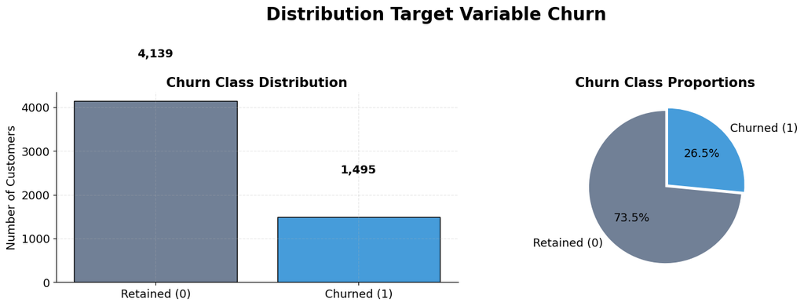

```python
fig, axes = plt.subplots(1, 2, figsize=(14, 5))

plt.suptitle("Distribution Target Variable Churn", y = 0.97)
churn_counts = train_df["Churn"].value_counts().sort_index()
colors = my_palette
axes[0].bar(["Retained (0)", "Churned (1)"], churn_counts.values, color=colors, edgecolor="black")
axes[0].set_title("Churn Class Distribution")
axes[0].set_ylabel("Number of Customers")
for i, v in enumerate(churn_counts.values):
    axes[0].text(i, v + 1000, f"{v:,}", ha="center", fontweight="bold")


axes[1].pie(churn_counts.values, labels=["Retained (0)", "Churned (1)"],
            autopct="%1.1f%%", colors=colors, startangle=90, explode=(0, 0.05))
axes[1].set_title("Churn Class Proportions")

plt.tight_layout()
plt.show()
```

**Results** Distribution of the Target Variable**

- **Class imbalance:** The target variable `Churn` exhibits a notable class imbalance in the training data. Approximately 73% of customers are retained ("No") and approximately 27% have churned ("Yes"). This asymmetry is characteristic of real-world churn datasets, where the majority of customers remain with the service provider at any given time.
- **Modeling implications:** The imbalance is moderate but not negligible. Without correction, classifiers may develop a bias toward predicting the majority class. This will be addressed in preprocessing by random oversampling/random undersampling.

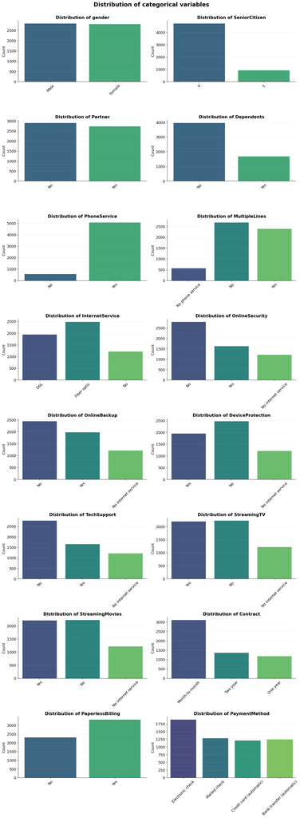

```python
fig, axes = plt.subplots(8, 2, figsize=(15, 40))
axes = axes.flatten()

plt.suptitle("Distribution of categorical variables", y = 1)

for i, col in enumerate(train_cat):
    sns.countplot(data=train_cat, x=col, ax=axes[i], palette="viridis")
    axes[i].set_title(f"Distribution of {col}")
    axes[i].set_xlabel("")
    axes[i].set_ylabel("Count")

    for tick in axes[i].get_xticklabels():
        tick.set_rotation(45)

for j in range(i + 1, len(axes)):
    axes[j].axis("off")

plt.tight_layout()
plt.show()
```

**Results** Distribution of Categorical Variables**

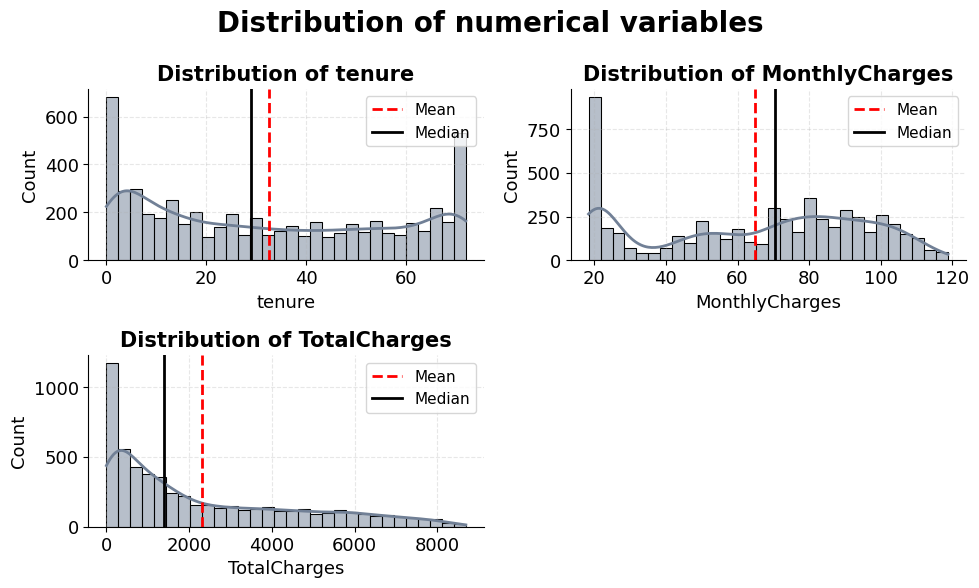

```python
fig, axes = plt.subplots(2, 2)
axes = axes.flatten()

plt.suptitle("Distribution of numerical variables", y = 0.98)

for i, col in enumerate(train_num):
    sns.histplot(train_num[col], kde=True, ax=axes[i], color=my_color1, bins=30)

    axes[i].axvline(train_num[col].mean(), color="red", linestyle="--", label="Mean")
    axes[i].axvline(train_num[col].median(), color="black", linestyle="-", label="Median")

    axes[i].set_title(f"Distribution of {col}")
    axes[i].legend()

for j in range(i + 1, len(axes)):
    axes[j].axis("off")

plt.tight_layout()
plt.show()
```

**Results** Distribution of Numerical Variables**

#### 2.2.2 Bivariate and Multivariate Analysis

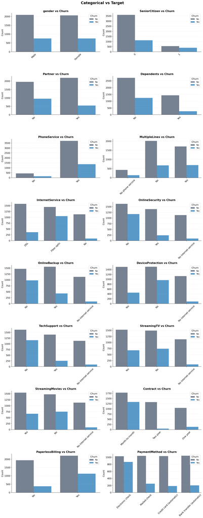

```python
fig, axes = plt.subplots(8, 2, figsize=(16, 40))
axes = axes.flatten()

plt.suptitle("Categorical vs Target", y = 1)

for i, col in enumerate(train_cat):
    sns.countplot(data=train_df, x=col, hue="Churn", ax=axes[i], palette=my_palette)

    axes[i].set_title(f"{col} vs Churn")
    axes[i].set_xlabel("")
    axes[i].set_ylabel("Count")

    for tick in axes[i].get_xticklabels():
        tick.set_rotation(45)

for j in range(i + 1, len(axes)):
    axes[j].axis("off")

plt.tight_layout()
plt.show()
```

**Results** Categorical Features vs. Target Variable**

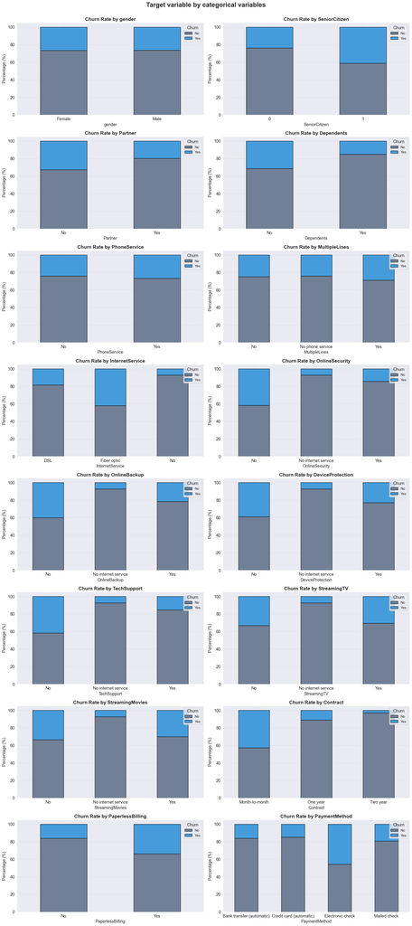

```python
sns.set_style("darkgrid", {"grid.color": ".6", "grid.linestyle": ":"})

fig, axes = plt.subplots(8, 2, figsize=(18, 40))
axes = axes.flatten()

plt.suptitle("Target variable by categorical variables", y = 1)

for i, col in enumerate(train_cat.columns):
    ct = pd.crosstab(train_df[col], train_df["Churn"], normalize="index") * 100

    ct.plot(kind="bar", stacked=True, ax=axes[i],
            color=my_palette, edgecolor="black")

    axes[i].set_title(f"Churn Rate by {col}")
    axes[i].set_ylabel("Percentage (%)")
    axes[i].set_xlabel(col)
    axes[i].legend_.set_loc("upper right")
    axes[i].tick_params(axis="x", rotation=0)

for j in range(i + 1, len(axes)):
    axes[j].axis("off")

plt.tight_layout()
plt.show()
```

**Results** Churn Rate by Categorical Variable**

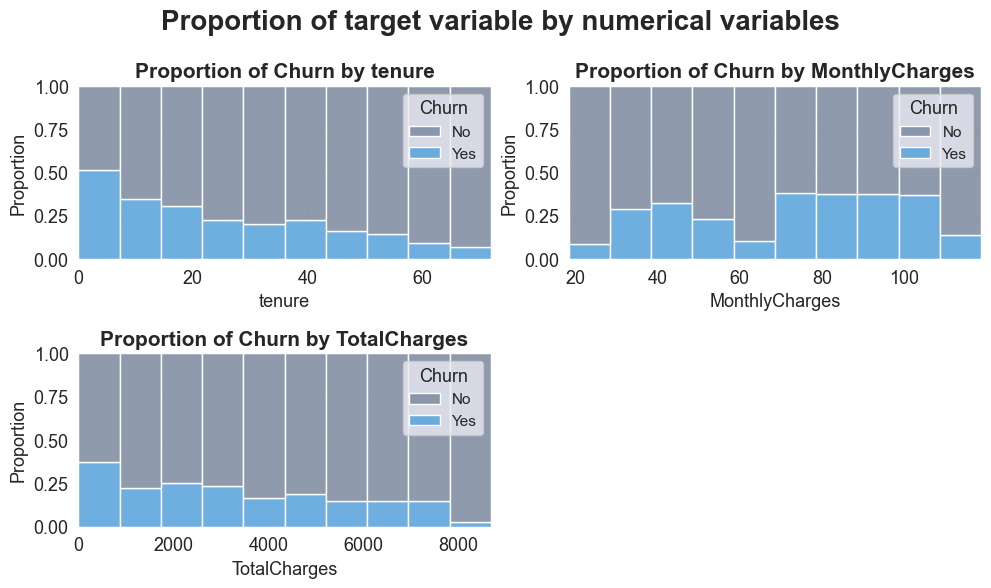

```python
fig, axes = plt.subplots(2, 2)
axes = axes.flatten()

plt.suptitle("Proportion of target variable by numerical variables")

for i, col in enumerate(train_num.columns):
    sns.histplot(data=train_df, x=col, hue="Churn", multiple="fill", ax=axes[i], bins=10, palette=my_palette)

    axes[i].set_title(f"Proportion of Churn by {col}")
    axes[i].set_ylabel("Proportion")
    axes[i].legend_.set_loc("upper right")

for j in range(i + 1, len(axes)):
    axes[j].axis("off")


plt.tight_layout()
plt.show()
```

**Results** Churn Proportion by Numerical Variables**

- **Tenure is a strong protective factor:** The churn proportion is highest among customers with short tenure (0–12 months) and declines a lot as tenure increases. Customers who have remained for 48+ months show very low churn rates. This confirms that early in the customer lifecycle is the highest risk of attrition.
- **Higher monthly charges are associated with more churn:** For `MonthlyCharges`, the proportion of churners increases at higher values. This may reflect customer sensitivity to price, particularly among those on premium or fiber optic plans who may think they do not get enough value.
- **High total charges are associated with retention:** Contradictorily, the pattern in `TotalCharges` shows that customers with very high cumulative charges have low churn rates. This reflects the moderating role of tenure: long-tenured customers accumulate high total charges and are, simultaneously, the most loyal.

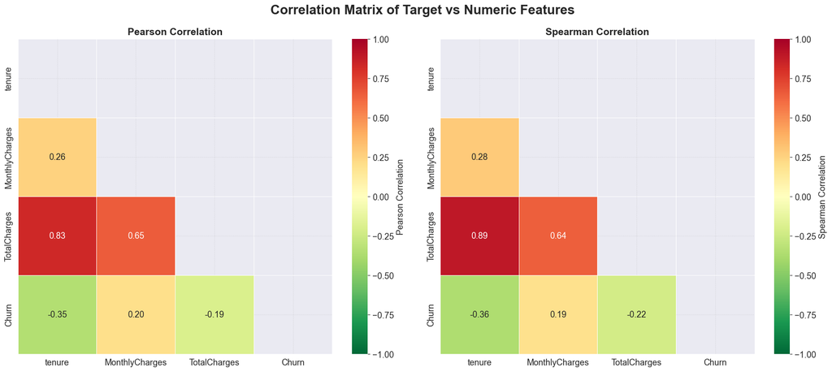

```python
corr_df = train_num.copy()
corr_df["Churn"] = train_df["Churn"].map({"Yes": 1, "No": 0})

corr_matrix = corr_df.corr()
corr_pearson = corr_df.corr(method="pearson")
corr_spearman = corr_df.corr(method="spearman")

fig, axes = plt.subplots(1, 2, figsize=(18, 8))

plt.suptitle("Correlation Matrix of Target vs Numeric Features")

mask_pearson = np.triu(np.ones_like(corr_pearson, dtype=bool))
mask_spearman = np.triu(np.ones_like(corr_spearman, dtype=bool))

sns.heatmap(corr_pearson, annot=True, fmt=".2f", cmap="RdYlGn_r",
            mask=mask_pearson, vmin=-1, vmax=1, linewidths=0.5,
            cbar_kws={"label": "Pearson Correlation"}, ax=axes[0])
axes[0].set_title("Pearson Correlation")

sns.heatmap(corr_spearman, annot=True, fmt=".2f", cmap="RdYlGn_r",
            mask=mask_spearman, vmin=-1, vmax=1, linewidths=0.5,
            cbar_kws={"label": "Spearman Correlation"}, ax=axes[1])
axes[1].set_title("Spearman Correlation")

plt.tight_layout()
plt.show()
```

**Results** Correlation Analysis — Numerical Features and Target**

- **TotalCharges is strongly correlated with both Tenure and MonthlyCharges:** Both Pearson and Spearman matrices show high positive correlations between `TotalCharges` and `tenure` (r ≈ 0.83) and between `TotalCharges` and `MonthlyCharges` (r ≈ 0.65). This is expected, as `TotalCharges` is basically a function of the other two variables. Since random forests do not estimate coefficients, this will not cause any mathematical problems.
- **Tenure is negatively associated with Churn:** A moderate negative correlation between `tenure` and `Churn` is consistent with the visual analysis: longer-tenured customers are less likely to churn.
- **MonthlyCharges is positively associated with Churn:** A moderate positive correlation between `MonthlyCharges` and `Churn` confirms the finding that higher-paying customers have greater churn tendency.
- **Consistency between Pearson and Spearman:** The two matrices produce near similar results, suggesting that the observed relationships are not only linear in nature and are flexible to monotonic transformations of the variables.

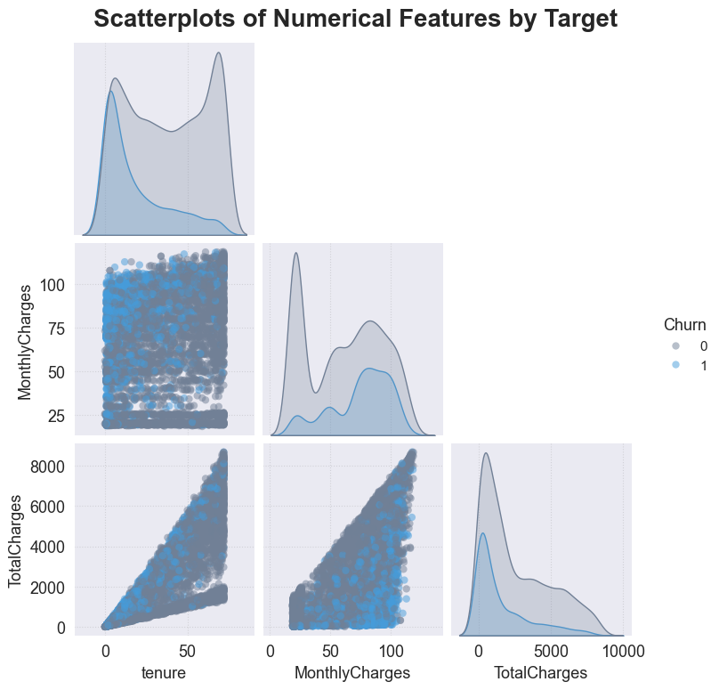

```python
sns.pairplot(corr_df, hue="Churn", palette=my_palette, corner=True,
             plot_kws={"alpha": 0.5, "edgecolor": "none"})

plt.suptitle("Scatterplots of Numerical Features by Target", y=1.03)
plt.show()
```

#### 2.2.3 Outlier Detection

We investigate whether outliers are present in our continuous features using two complementary approaches:

**1. univariate detection** via boxplots and a logical consistency check.

**2. multivariate detection** via Isolation Forest.

The goal is to determine whether any extreme values represent data errors (exogenous outliers) that should be removed, or valid but rare customer behaviours (endogenous outliers) that should be kept.

First, we use the IQR method to visualize extreme values.

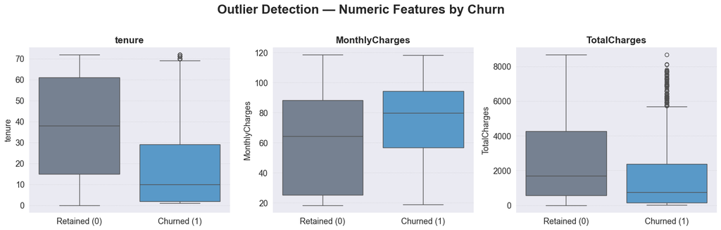

```python
fig, axes = plt.subplots(1, 3, figsize=(16, 5))
plt.suptitle("Outlier Detection — Numeric Features by Churn", y=1.01)

for i, col in enumerate(train_num.columns):
    sns.boxplot(data=train_df, x="Churn", y=col,
                ax=axes[i], palette=my_palette,
                hue="Churn", legend=False)
    axes[i].set_title(f"{col}")
    axes[i].set_xlabel("")
    axes[i].set_ylabel(col)
    axes[i].set_xticks([0, 1])
    axes[i].set_xticklabels(["Retained (0)", "Churned (1)"])

plt.tight_layout()
plt.show()
```

**Results** Outlier Investigation & Distribution Analysis**

- **Univariate Numeric Observation:** The boxplots reveal specific extreme values across the features: **TotalCharges** shows several dots between 6000–8500 in the "Churned" group, and **Tenure** shows 1–2 points slightly above 70. **MonthlyCharges** shows no outliers, indicating all billing rates are within standard plan limits.
- **High-Value Churners:** The outliers in the "TotalCharges" boxplot are not data errors; they represent long-term customers who stayed for a significant period and paid a high cumulative amount before leaving. They appear as outliers because most churners leave the company much earlier, resulting in much lower average total charges for that group.

We aim to demonstrate that these extreme values are **endogenous outliers**, i.e., valid, structural data points reflecting real customer behaviors (such as long-term retention on premium plans) rather than exogenous outliers resulting from measurement errors or data corruption.

##### a) Univariate Testing

We examine the outliers of `TotalCharges`. Since `TotalCharges` should logically equal `Tenure` × `MonthlyCharges`, we’ll plot the actual vs. the theoretical values. If the outliers sit on the theoretical line, they aren"t measurement errors, but just the most profitable, long-term users.

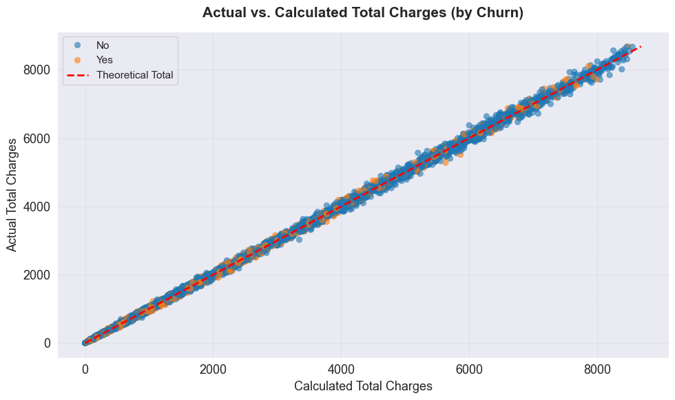

```python
check_df = train_df[["tenure", "MonthlyCharges", "TotalCharges", "Churn"]].copy()
check_df["CalculatedTotal"] = check_df["tenure"] * check_df["MonthlyCharges"]

plt.figure(figsize=(10, 6))

sns.scatterplot(x="CalculatedTotal", y="TotalCharges", hue="Churn", data=check_df, alpha=0.6, edgecolor=None)

max_val = max(check_df["CalculatedTotal"].max(), check_df["TotalCharges"].max())
plt.plot([0, max_val], [0, max_val], color="red", linestyle="--", linewidth=2, label="Theoretical Total")

plt.title("Actual vs. Calculated Total Charges (by Churn)", pad=15)
plt.xlabel("Calculated Total Charges")
plt.ylabel("Actual Total Charges")
plt.legend()
plt.grid(True, alpha=0.3)

plt.tight_layout()
plt.show()
```

**Results** Actual vs Calculated Total Charges**

- **Nearly perfect linear correlation:** The data points flagged as (statistical) outliers do not deviate from the reference line.
- We will retain these extreme values in the training set, as they represent valuable customer behavior.

##### b) Multivariate Testing

Next, we’ll use an `IsolationForest` to see if any rows have "weird" feature combinations that univariate checks miss.

```python
train_cat_encoded = pd.get_dummies(train_cat, drop_first=True)

df_encoded = pd.concat([train_num, train_cat_encoded], axis=1)

iso_forest = IsolationForest(contamination=0.01, random_state=SEED)

outliers = iso_forest.fit_predict(df_encoded)
train_df["is_outlier"] = outliers

print(train_df[["is_outlier", "Churn"]].value_counts())
n_outliers = (outliers == -1).sum()
print(f"Outliers detected: {n_outliers} ({n_outliers/len(train_df)*100:.1f}%) at 1% contamination level")
```

```
is_outlier  Churn
 1          No       4082
            Yes      1495
-1          No         57
Name: count, dtype: int64
Outliers detected: 57 (1.0%) at 1% contamination level
```

**Results** Outlier Investigation & Distribution Analysis**

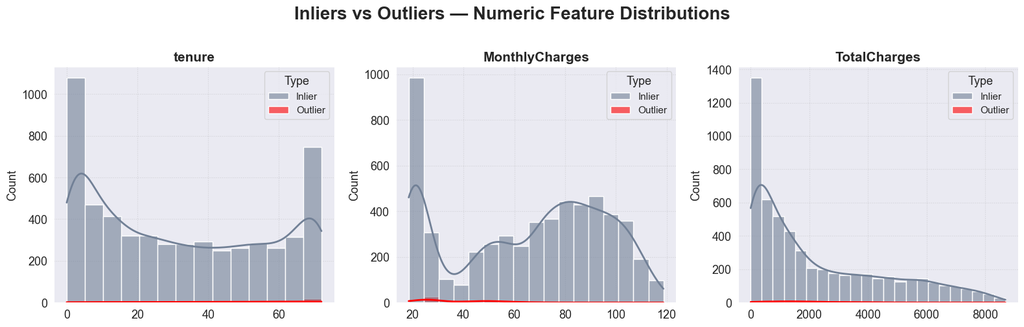

```python
fig, axes = plt.subplots(1, 3, figsize=(16, 5))
plt.suptitle("Inliers vs Outliers — Numeric Feature Distributions", y=1.01)

for i, col in enumerate(train_num.columns):
    sns.histplot(data=train_df, x=col, hue="is_outlier",
                 ax=axes[i], palette={1: my_palette[0], -1: "red"},
                 hue_order=[1, -1],
                 kde=True, alpha=0.6)
    axes[i].set_title(f"{col}")
    axes[i].set_xlabel("")
    axes[i].set_ylabel("Count")

    legend = axes[i].get_legend()
    if legend:
        legend.set_title("Type")
        for t, label in zip(legend.get_texts(), ["Inlier", "Outlier"]):
            t.set_text(label)

plt.tight_layout()
plt.show()
```

**Results** Outlier Investigation & Distribution Analysis**

```python
outlier_profile = train_df.groupby("is_outlier")[["tenure", "MonthlyCharges", "TotalCharges"]].mean().round(2)
outlier_profile.index = ["Outliers (-1)", "Inliers (1)"]
outlier_profile.index.name = None
print("Average feature values by outlier status:")
print(outlier_profile)

train_df = train_df.drop("is_outlier", axis=1)
```

```
Average feature values by outlier status:
               tenure  MonthlyCharges  TotalCharges
Outliers (-1)   45.95           36.25       1704.13
Inliers (1)     32.35           65.22       2305.42
```

**Results** Outlier Profiles**

- **Profile:** High average tenure (around 46 months) combined with low monthly charges (around 36$).
- **Interpretation:** Customers who have subscribed to a single basic service e.g. a landline and have remained with the company for years.

While some combinations are statistically rare compared to the rest of the dataset, it is a logically valid customer segment. We will retain all rows to ensure the model learns to recognize these high-tenure, low-spend patterns.

# 3 Data Preprocessing

```python
X_train = train_df.drop("Churn", axis = 1)
y_train = train_df["Churn"]

X_test = test_df.drop("Churn", axis = 1)
y_test = test_df["Churn"]
```

```python
y_train = y_train.map({"Yes": 1, "No": 0})
y_test = y_test.map({"Yes": 1, "No": 0})
```

Based on the findings from EDA, we can derive the following necessary preprocessing steps:

1. **Class Imbalance:** The target variable is imbalanced (≈73% retained, ≈27% churned). Three resampling strategies are evaluated as tunable pipeline steps: `RandomOverSampler`, `RandomUnderSampler`, and `SMOTENC`. Every strategy has certain disadvantages, which is why the optimal strategy will be selected by `GridSearchCV`.
2. **Multicollinearity:** Multicollinearity is present in two forms:
   - `TotalCharges` is strongly correlated with both `tenure` (r ≈ 0.83) and `MonthlyCharges` (r ≈ 0.65), as it is effectively their product.
   - Service add-on features such as `OnlineSecurity` and `TechSupport` share a structural *"No internet service"* category, making them collinear by construction.

   Since the models we are going to use are not so much affected by multicollinearity we will not treat multicollinearity nor drop any features.
3. **Scaling:** Numeric features (`tenure`, `MonthlyCharges`, `TotalCharges`) are standardised due to their their different scale in comparison to the other features. We are using `StandardScaler` (using z-standardization instead of normalization) for this, since we have skewed, continuous data, e.g. `Total Charges` is heavily right-skewed.
4. **Encoding:** Nominal categorical features are one-hot encoded. `Contract` is ordinal encoded with a meaningful order (Month-to-month < One year < Two year) to preserve its natural ranking.

```python
num_cols = train_num.columns.tolist() # to scale
onehot_cols = [col for col in train_cat.columns.tolist() if col != "Contract"] # to onehot encode
ordinal_cols = ["Contract"] # to ordinal encode

contract_order = ["Month-to-month", "One year", "Two year"]
```

```python
class Preprocessor(BaseEstimator, TransformerMixin):
    def __init__(self, num_var, onehot_var, ordinal_var):
        self.num_var = num_var
        self.onehot_var = onehot_var
        self.ordinal_var = ordinal_var
        self.preprocessor = None

    def fit(self, X, y = None):
        numeric_transformer = StandardScaler()
        onehot_transformer = OneHotEncoder()
        ordinal_transformer = OrdinalEncoder(
            categories = [contract_order]
        )

        self.preprocessor = ColumnTransformer([
            ("num", numeric_transformer, self.num_var),
            ("onehot", onehot_transformer, self.onehot_var),
            ("ordinal", ordinal_transformer, self.ordinal_var)
        ], remainder = "passthrough", force_int_remainder_cols = False, verbose_feature_names_out = False)

        self.preprocessor.fit(X)


        return self

    def transform(self, X):
        X_transformed = self.preprocessor.transform(X)
        return X_transformed

    def get_feature_names(self, input_features = None):
        return self.preprocessor.get_feature_names_out(input_features)
```

```python
# For saving purposes only

preprocessor = Preprocessor(
    num_var = num_cols,
    onehot_var = onehot_cols,
    ordinal_var = ordinal_cols
)

X_train_processed = preprocessor.fit_transform(X_train)
X_test_processed = preprocessor.transform(X_test)
feature_names = preprocessor.get_feature_names()

train_processed_df = pd.DataFrame(
     X_train_processed,
     columns=feature_names,
     index=X_train.index
)

test_processed_df = pd.DataFrame(
     X_test_processed,
     columns=feature_names,
     index=X_test.index
)

train_processed_df["Churn"] = y_train
test_processed_df["Churn"] = y_test

train_processed_df.to_csv("../data/train_processed.csv", index=False)
test_processed_df.to_csv("../data/test_processed.csv", index=False)
```

```python
def make_preprocessor():
    return Preprocessor(
    num_var = num_cols,
    onehot_var = onehot_cols,
    ordinal_var = ordinal_cols
)
```

```python
cat_indices = [X_train.columns.get_loc(col) for col in train_cat]

sampling_strategies = [
    RandomOverSampler(random_state=SEED),
    RandomUnderSampler(random_state=SEED),
    SMOTENC(random_state=SEED, categorical_features=cat_indices)
]
```

# 4 Modeling

The modeling part contains the investigation of four different models: a dummy baseline, a Decision Tree, a Random Forest, and a simple Neural Network. Except for the baseline, all models are tuned using `GridSearchCV` with a stratified 5-fold cross-validation, ensuring that the class ratio is preserved in every fold, and scored on ROC-AUC. We use ROC-AUC because we value the ranking ability of this metric more than the performance at any single fixed threshold.

```python
skf = StratifiedKFold(n_splits = 5, shuffle = True, random_state = SEED)
```

```python
model_results = {} # to store the results of different models
```

```python
def build_model(model_id, model, param_grid, scoring = "roc_auc", X_train = X_train, y_train = y_train):
    """Function to train the model using GridSearchCV,
    printing the best score and saving the results.

    Args:
        model_id (str): Name of the model
        model (estimator): Model to train
        param_grid (dict): parameters for the grid_search
        scoring (str, optional): evaluation metric. Defaults to "roc_auc".
        X_train (pd.DataFrame, optional): X_train data. Defaults to X_train.
        y_train (pd.Series, optional): y_train data. Defaults to y_train.
    """

    grid_search = GridSearchCV(
        estimator = model,
        param_grid = param_grid,
        cv = skf,
        scoring = scoring,
        n_jobs = -1
    )

    grid_search.fit(X_train, y_train)

    print(f"Best Parameters: {grid_search.best_params_}")
    print(f"Best Score ({scoring}): {grid_search.best_score_:.4f}")

    model_results[model_id] = {
        "best_estimator": grid_search.best_estimator_,
        "best_score": grid_search.best_score_,
        "validation_results": grid_search.cv_results_
    }

    return grid_search
```

### 4.1 Baseline Model

```python
baseline_pipeline = ImbPipeline([
    ("preprocessor", make_preprocessor()),
    ("classifier", DummyClassifier(strategy="most_frequent"))
])
```

```python
baseline_model = baseline_pipeline.fit(X_train, y_train)
```

**Results** Modelling: Baseline**

- **Dummy Classifier:** the baseline model always predicts the majority class (Retained)

### 4.2 Decision Tree

```python
dt_pipeline = ImbPipeline([
    ("sampler", "passthrough"),
    ("preprocessor", make_preprocessor()),
    ("classifier", DecisionTreeClassifier(random_state=SEED))
])
```

```python
dt_param_grid = {
    "sampler": sampling_strategies,
    "sampler__sampling_strategy": [0.6, 0.8, 1.0],
    "classifier__max_depth": [3, 5, 7],
    "classifier__min_samples_split": [2, 5, 10],
    "classifier__min_samples_leaf": [8, 12],
    "classifier__max_features": ["sqrt", "log2", None]

}

dt_results = build_model(
    model_id="Decision Tree",
    model=dt_pipeline,
    param_grid=dt_param_grid
)
```

```
Best Parameters: {'classifier__max_depth': 5, 'classifier__max_features': None, 'classifier__min_samples_leaf': 12, 'classifier__min_samples_split': 2, 'sampler': RandomUnderSampler(random_state=42), 'sampler__sampling_strategy': 0.8}
Best Score (roc_auc): 0.8309
```

```python
dt_param_grid2 = {
    "sampler": sampling_strategies,
    "sampler__sampling_strategy": [0.6, 0.8, 1.0],
    "classifier__max_depth": [3, 5, 7],
    "classifier__min_samples_split": [2, 5, 10],
    "classifier__min_samples_leaf": [8, 12, 14],
    "classifier__max_features": ["sqrt", "log2", None]

}

dt_results = build_model(
    model_id="Decision Tree",
    model=dt_pipeline,
    param_grid=dt_param_grid2
)
```

```
Best Parameters: {'classifier__max_depth': 5, 'classifier__max_features': None, 'classifier__min_samples_leaf': 14, 'classifier__min_samples_split': 2, 'sampler': RandomUnderSampler(random_state=42), 'sampler__sampling_strategy': 0.8}
Best Score (roc_auc): 0.8326
```

```python
dt_param_grid3 = {
    "sampler": sampling_strategies,
    "sampler__sampling_strategy": [0.6, 0.8, 1.0],
    "classifier__max_depth": [3, 5, 7],
    "classifier__min_samples_split": [2, 5, 10],
    "classifier__min_samples_leaf": [8, 12, 14, 16],
    "classifier__max_features": ["sqrt", "log2", None]

}

dt_results = build_model(
    model_id="Decision Tree",
    model=dt_pipeline,
    param_grid=dt_param_grid3
)
```

```
Best Parameters: {'classifier__max_depth': 5, 'classifier__max_features': None, 'classifier__min_samples_leaf': 14, 'classifier__min_samples_split': 2, 'sampler': RandomUnderSampler(random_state=42), 'sampler__sampling_strategy': 0.8}
Best Score (roc_auc): 0.8326
```

**Results** Modelling: Decision Tree Forest with GridSearchCV**

**Methodology:** We iteratively refined our Decision Tree pipeline across 5 folds with `GridSearchCV` by expanding the search space sequentially. While the overall performance did not shift dramatically, this systematic tuning yielded a measurable improvement in the cross-validated ROC-AUC score, increasing it from approximately 0.8309 to 0.8326.

The final results are shown below:

- **Best Cross-Validation ROC AUC:** 0.8326
- **Best Hyperparameters:**
  - **Maximum Depth:** 5
  - **Maximum Features:** None *(all features considered)*
  - **Minimum Samples per Leaf:** 14
  - **Minimum Samples to Split:** 2
  - **Sampling Method:** RandomUnderSampler (random_state = 42)
  - **Sampling Ratio:** 0.8